# Manipulation check analysis

# 0. Rationale

This file presents the results of the manipulation check experiment.

We begin by importing the raw data and creating a dataset. The `extract` function retrieves the specified data from each raw file and compiles the results into a single dataset, shown below.

```r
rm(list=ls())
set.seed(2026)

library(tidyverse)  # dplyr, tidyr, ggplot2
library(janitor)
library(DT)

# CSV original column names
singleton_orig <- c("PROLIFIC_PID", "date", "OS",
  "tempo_consenso", "InstTot.started", "InstTot.stopped",
  "QUEST.block_1/AGE", "QUEST.block_1/SEX", "QUEST.block_1/Education level", "Ant_lastquestion.stopped")
trial_orig <- c("tempo_Testo", "condizione",
  "tempo_vd1",   "previous.response", "tempo_prob1", "previous_2.response",
  "tempo_prob2", "previous_3.response")
n_trials <- 3
singleton_clean <- janitor::make_clean_names(singleton_orig)
trial_clean     <- janitor::make_clean_names(trial_orig)
singleton_labels <- singleton_clean
trial_labels     <- unlist(lapply(trial_clean, function(v)
  paste0(v, "_trial", seq_len(n_trials))))

all_labels <- c(singleton_labels, trial_labels)

# Extraction function
extract <- function(file_path) {
  dataset <- tryCatch(read.csv(file_path,
                               stringsAsFactors = FALSE,
                               check.names = FALSE),
    error = function(e) NULL)
  if (is.null(dataset))
    return(setNames(rep(NA, length(all_labels)), all_labels))

  colnames(dataset) <- janitor::make_clean_names(colnames(dataset))

  result <- list()
    for (i in seq_along(singleton_clean)) {
    v     <- singleton_clean[i]
    label <- singleton_labels[i]
    if (v %in% colnames(dataset)) {
      non_na <- dataset[[v]][!is.na(dataset[[v]]) & dataset[[v]] != ""]
      result[[label]] <- if (length(non_na) > 0) non_na[1] else NA
    } else {
      result[[label]] <- NA
    }
  }
    for (i in seq_along(trial_clean)) {
    v      <- trial_clean[i]
    non_na <- if (v %in% colnames(dataset))
      dataset[[v]][!is.na(dataset[[v]]) & dataset[[v]] != ""]
    else character(0)
    padded     <- rep(NA_character_, n_trials)
    take       <- min(length(non_na), n_trials)
    if (take > 0) padded[seq_len(take)] <- as.character(non_na[seq_len(take)])
    for (t in seq_len(n_trials))
      result[[paste0(v, "_trial", t)]] <- padded[t]
  }

  return(unlist(result[all_labels]))
}

# Raw data folder
file_paths <- list.files(
  path        = file.path(getwd(), "RAW12_ANON"),
  pattern     = "\\.csv$",
  full.names  = TRUE
)
if (length(file_paths) == 0)
  stop("No CSV files found.")

results  <- lapply(file_paths, extract)
dfa_wide <- as.data.frame(do.call(rbind, results), stringsAsFactors = FALSE)
colnames(dfa_wide) <- all_labels
dfa_wide <- cbind(source_file = basename(file_paths), dfa_wide)

singleton_numeric <- intersect(names(dfa_wide), c(
  "tempo_consenso", "insttot_started", "insttot_stopped",
  "quest_block_1_age", "quest_block_1_education_level",
  "ant_lastquestion_stopped"
))
trial_numeric <- grep("^(tempo_|previous)", names(dfa_wide), value = TRUE)
numeric_cols <- unique(c(singleton_numeric, trial_numeric))
dfa_wide[numeric_cols] <- lapply(dfa_wide[numeric_cols], function(x) as.numeric(as.character(x)))
char_cols <- grep("^condizione_|^quest_block_1_sex$", names(dfa_wide),
                  value = TRUE)
dfa_wide[char_cols] <- lapply(dfa_wide[char_cols], function(x) {
  tolower(trimws(as.character(x)))
})
dfa_long <- dfa_wide %>%
  pivot_longer(
    cols      = all_of(trial_labels),
    names_to  = c(".value", "trial_num"),
    names_pattern = "^(.+)_(trial\\d+)$"
  ) %>%
  mutate(trial_num = as.integer(sub("trial", "", trial_num))) %>%
  relocate(source_file, prolific_pid, trial_num, condizione)

# Long dataset
dt_long <- datatable(
  dfa_long,
  caption = "Long dataset (1 row per trial)",
  options = list(scrollX = "400px", scrollY = "300px",
                 scrollCollapse = TRUE, pageLength = 5, autoWidth = TRUE),
  class = "cell-border stripe compact"
) |> formatStyle(names(dfa_long), lineHeight = ".3em", padding = "1px")
dt_long
```

|  | source_file | prolific_pid | trial_num | condizione | date | os | tempo_consenso | inst_tot_started | inst_tot_stopped | quest_block_1_age | quest_block_1_sex | quest_block_1_education_level | ant_lastquestion_stopped | tempo_testo | tempo_vd1 | previous_response | tempo_prob1 | previous_2_response | tempo_prob2 | previous_3_response |
| --- | --- | --- | --- | --- | --- | --- | --- | --- | --- | --- | --- | --- | --- | --- | --- | --- | --- | --- | --- | --- |
| 1 | PROLIFIC_PID_CLTandFLE_2026-06-19_17h48.47.823.csv | P001 | 1 | l | 2026-06-19_17h48.47.823 | Win32 | 7.7349 | 38.8521 | 50.2803 | 24 | fe | 4 | 326.9864 | 29.0513 | 9.1234 | 52 | 21.9815 | 100 | 23.8967 | 34 |
| 2 | PROLIFIC_PID_CLTandFLE_2026-06-19_17h48.47.823.csv | P001 | 2 | m | 2026-06-19_17h48.47.823 | Win32 | 7.7349 | 38.8521 | 50.2803 | 24 | fe | 4 | 326.9864 | 23.7024 | 49.9866 | 18 | 15.2554 | 36 | 15.6674 | 42 |
| 3 | PROLIFIC_PID_CLTandFLE_2026-06-19_17h48.47.823.csv | P001 | 3 | a | 2026-06-19_17h48.47.823 | Win32 | 7.7349 | 38.8521 | 50.2803 | 24 | fe | 4 | 326.9864 | 9.6807 | 10.0671 | 26 | 6.3108 | 42 | 6.3878 | 11 |
| 4 | PROLIFIC_PID_CLTandFLE_2026-06-19_17h57.24.780.csv | P002 | 1 | m | 2026-06-19_17h57.24.780 | Win32 | 28.5238 | 52.1661 | 70.1959 | 22 | fe | 4 | 423.8439 | 34.1158 | 29.1129 | 99 | 18.6148 | 99 | 34.225 | 1 |
| 5 | PROLIFIC_PID_CLTandFLE_2026-06-19_17h57.24.780.csv | P002 | 2 | a | 2026-06-19_17h57.24.780 | Win32 | 28.5238 | 52.1661 | 70.1959 | 22 | fe | 4 | 423.8439 | 23.571 | 11.2652 | 95 | 28.5338 | 99 | 22.1477 | 0 |
| 6 | PROLIFIC_PID_CLTandFLE_2026-06-19_17h57.24.780.csv | P002 | 3 | l | 2026-06-19_17h57.24.780 | Win32 | 28.5238 | 52.1661 | 70.1959 | 22 | fe | 4 | 423.8439 | 27.6391 | 24.9312 | 99 | 17.7793 | 99 | 19.7636 | 0 |
| 7 | PROLIFIC_PID_CLTandFLE_2026-06-19_18h46.41.072.csv | P003 | 1 | l | 2026-06-19_18h46.41.072 | Win32 | 25.7937 | 37.1625 | 55.2321 | 23 | ma | 3 | 336.4762 | 40.3469 | 16.8891 | 62 | 20.7702 | 91 | 26.2832 | 1 |
| 8 | PROLIFIC_PID_CLTandFLE_2026-06-19_18h46.41.072.csv | P003 | 2 | a | 2026-06-19_18h46.41.072 | Win32 | 25.7937 | 37.1625 | 55.2321 | 23 | ma | 3 | 336.4762 | 21.8031 | 14.7576 | 67 | 21.1368 | 95 | 15.9735 | 0 |
| 9 | PROLIFIC_PID_CLTandFLE_2026-06-19_18h46.41.072.csv | P003 | 3 | m | 2026-06-19_18h46.41.072 | Win32 | 25.7937 | 37.1625 | 55.2321 | 23 | ma | 3 | 336.4762 | 16.6229 | 11.7262 | 63 | 9.8772 | 70 | 10.2104 | 20 |
| 10 | PROLIFIC_PID_CLTandFLE_2026-06-19_18h54.35.637.csv | P004 | 1 | l | 2026-06-19_18h54.35.637 | Win32 | 10.981 | 30.6845 | 49.154 | 19 | ma | 3 | 467.8597 | 64.8529 | 9.6602 | 31 | 21.6905 | 100 | 69.2356 | 13 |

[output cut: 203 more lines]

# 1. Exclusion criteria

```r
dfa_wide_raw <- dfa_wide
dfa_long_raw <- dfa_long

exclusion_flags <- dfa_long_raw %>%
  mutate(.durata_istruzioni = as.numeric(inst_tot_stopped) -
           as.numeric(inst_tot_started)) %>%
  group_by(prolific_pid) %>%
  summarise(
    flag_tempo_testo = any(tempo_testo  < 5, na.rm = TRUE),
    flag_istruzioni   = any(.durata_istruzioni < 5, na.rm = TRUE),
    flag_tempo_vd1    = any(tempo_vd1   < 2, na.rm = TRUE),
    flag_tempo_prob1  = any(tempo_prob1 < 2, na.rm = TRUE),
    flag_tempo_prob2  = any(tempo_prob2 < 2, na.rm = TRUE),
    flag_iphone       = any(os == "iPhone", na.rm = TRUE),
    .groups = "drop"
  ) %>%
  mutate(
    excluded = flag_tempo_testo | flag_istruzioni | flag_tempo_vd1 |
      flag_tempo_prob1 | flag_tempo_prob2 | flag_iphone
  )

exclusion_report <- exclusion_flags %>% filter(excluded)

summary_counts <- data.frame(
  Metric = c("Total participants", "Participants excluded", "Participants remaining"),
  Value = c(n_distinct(dfa_long_raw$prolific_pid), sum(exclusion_flags$excluded), sum(!exclusion_flags$excluded))
)
knitr::kable(summary_counts, caption = "Exclusion Criteria")
```

Exclusion Criteria

| Metric | Value |
| --- | --- |
| Total participants | 71 |
| Participants excluded | 6 |
| Participants remaining | 65 |

```r
excluded_pids <- exclusion_flags$prolific_pid[exclusion_flags$excluded]

# Riscriviamo i dataset filtrando via i soggetti esclusi
dfa_wide <- dfa_wide_raw %>% filter(!prolific_pid %in% excluded_pids)
dfa_long <- dfa_long_raw %>% filter(!prolific_pid %in% excluded_pids)

n_partecipanti_post_esclusione <- n_distinct(dfa_wide$prolific_pid)
```

# 2. Participants description

The final sample, after applying the exclusion criteria, included 65 participants.

## 2.1 Biological sex

We visualized the distribution of biological sex across the final sample.

```r
knitr::kable(table(dfa_wide$quest_block_1_sex))
```

| Var1 | Freq |
| --- | --- |
| fe | 33 |
| ma | 32 |

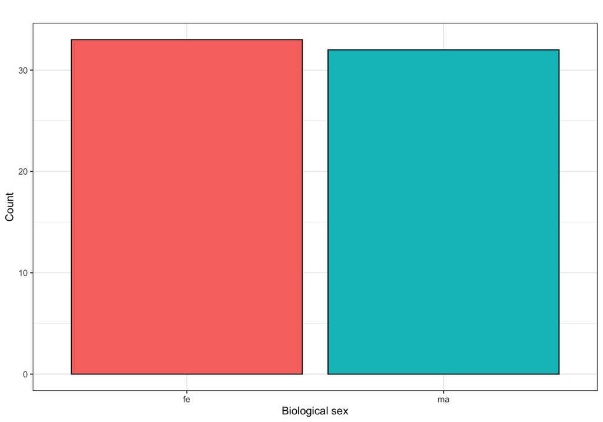

```r
ggplot(dfa_wide, aes(x = quest_block_1_sex, fill = quest_block_1_sex)) +
  geom_bar(color = "black") +
  theme_bw(base_size = 13) +
  labs(x = "Biological sex", y = "Count", title = "") +
  theme(legend.position = "none")
```

## 2.2 Age

We first calculate descriptive statistics and then visualize the distribution.

```r
knitr::kable(t(summary(dfa_wide$quest_block_1_age)))
```

| Min. | 1st Qu. | Median | Mean | 3rd Qu. | Max. |
| --- | --- | --- | --- | --- | --- |
| 18 | 21 | 22 | 21.96923 | 23 | 24 |

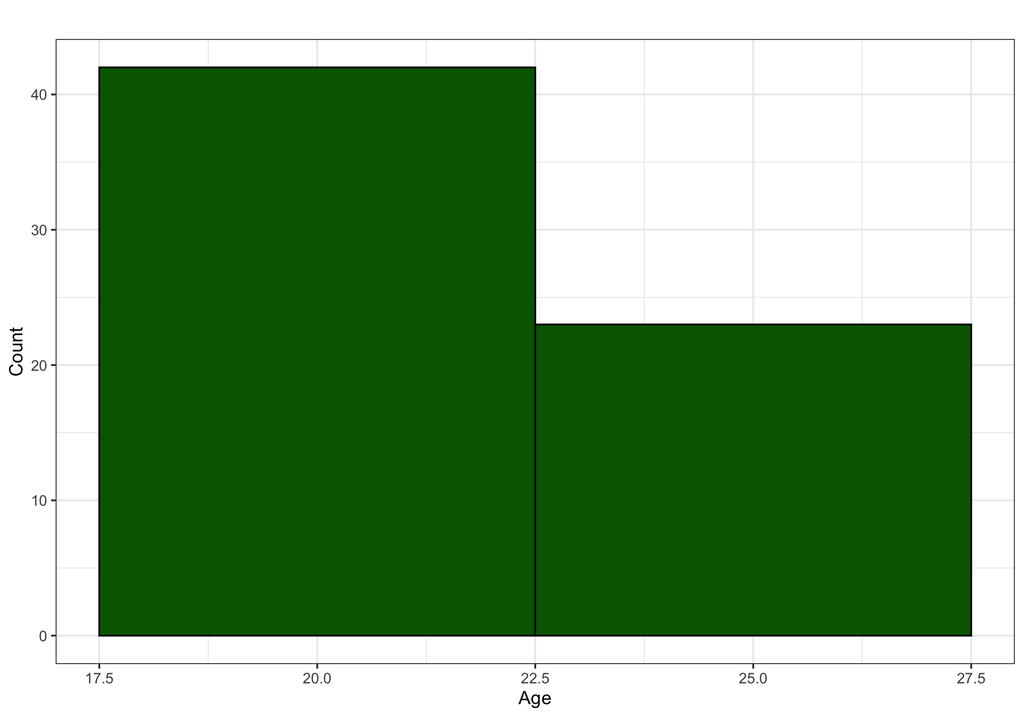

```r
ggplot(dfa_wide, aes(x = quest_block_1_age)) +
  geom_histogram(binwidth = 5, color = "black", fill = "darkgreen") +
  theme_bw(base_size = 13) +
  labs(x = "Age", y = "Count", title = "")
```

## 2.3 Education

We first calculate descriptive statistics and then visualize the distribution (3 = High School, 4 = Bachelor Degree, 5 = Master Degree).

```r
knitr::kable(table(dfa_wide$quest_block_1_education_level))
```

| Var1 | Freq |
| --- | --- |
| 3 | 27 |
| 4 | 37 |
| 5 | 1 |

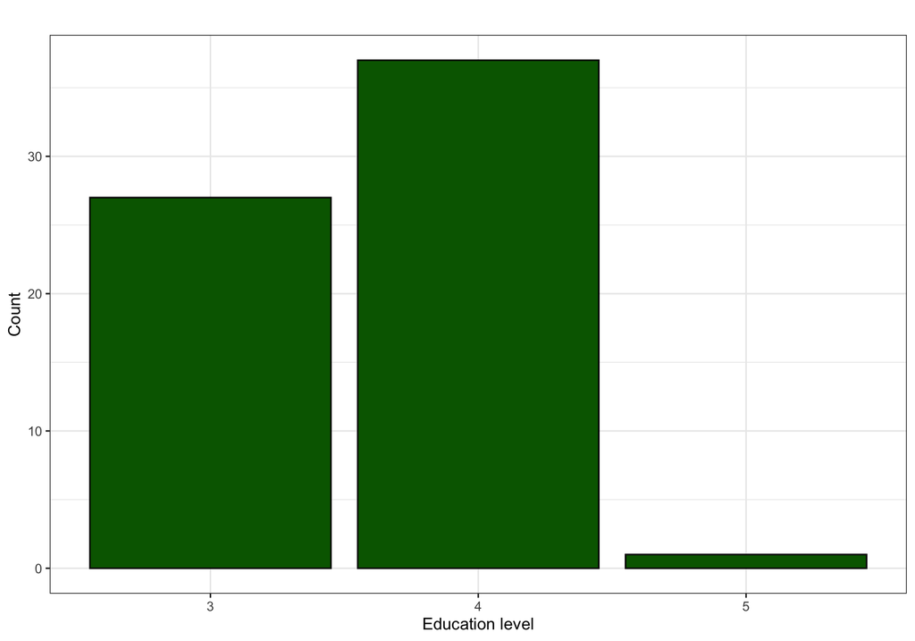

```r
ggplot(dfa_wide, aes(x = factor(quest_block_1_education_level))) +
  geom_bar(color = "black", fill = "darkgreen") +
  theme_bw(base_size = 13) +
  labs(x = "Education level", y = "Count", title = "")
```

# 3. Responses

For each of the three response variables below, we first calculate descriptive statistics by condition and then visualize the distribution.

## 3.1 Prior knowledge

`previous_response` captures participants’ prior knowledge of the causal relationship.

```r
tab_aspettativa_priori <- dfa_long %>%
  group_by(condizione) %>%
  summarise(
    Media = round(mean(previous_response, na.rm = TRUE), 2),
    SD    = round(sd(previous_response, na.rm = TRUE), 2),
    `% responses >50` = paste0(round(mean(previous_response > 50,
                                         na.rm = TRUE) * 100, 1), "%"),
    .groups = "drop"
  ) %>%
  rename(Condizione = condizione)

knitr::kable(tab_aspettativa_priori, caption = "Prior knowledge", align = "c")
```

Prior knowledge

| Condizione | Media | SD | % responses >50 |
| --- | --- | --- | --- |
| a | 52.46 | 23.54 | 43.1% |
| l | 70.22 | 17.77 | 81.5% |
| m | 68.66 | 19.33 | 78.5% |

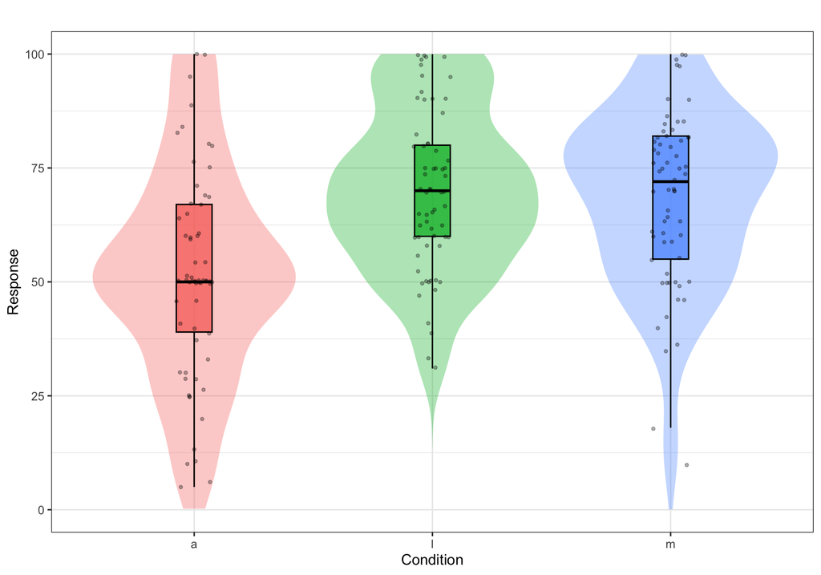

```r
ggplot(dfa_long, aes(x = condizione, y = previous_response, fill = condizione)) +
  geom_violin(alpha = 0.35, trim = FALSE, color = NA) +
  geom_boxplot(width = 0.15, outlier.shape = NA, alpha = 0.8, color = "black") +
  geom_jitter(width = 0.08, alpha = 0.3, size = 1, color = "black") +
  ylim(c(0, 100)) +
  theme_bw(base_size = 13) +
  labs(x = "Condition", y = "Response", title = "") +
  theme(legend.position = "none")
```

## 3.2 Deterministic judgment (when the cause is present)

`previous_2_response` captures participants’ deterministic judgment (when the candidate cause is present).

```r
tab_causa_presente <- dfa_long %>%
  group_by(condizione) %>%
  summarise(
    Media = round(mean(previous_2_response, na.rm = TRUE), 2),
    SD    = round(sd(previous_2_response, na.rm = TRUE), 2),
    `% responses >95` = paste0(round(mean(previous_2_response > 95,
                                         na.rm = TRUE) * 100, 1), "%"),
    .groups = "drop"
  ) %>%
  rename(Condizione = condizione)

knitr::kable(tab_causa_presente, caption = "Deterministic judgment (i)",
             align = "c")
```

Deterministic judgment (i)

| Condizione | Media | SD | % responses >95 |
| --- | --- | --- | --- |
| a | 80.11 | 21.15 | 30.8% |
| l | 87.02 | 17.51 | 40% |
| m | 84.72 | 14.18 | 24.6% |

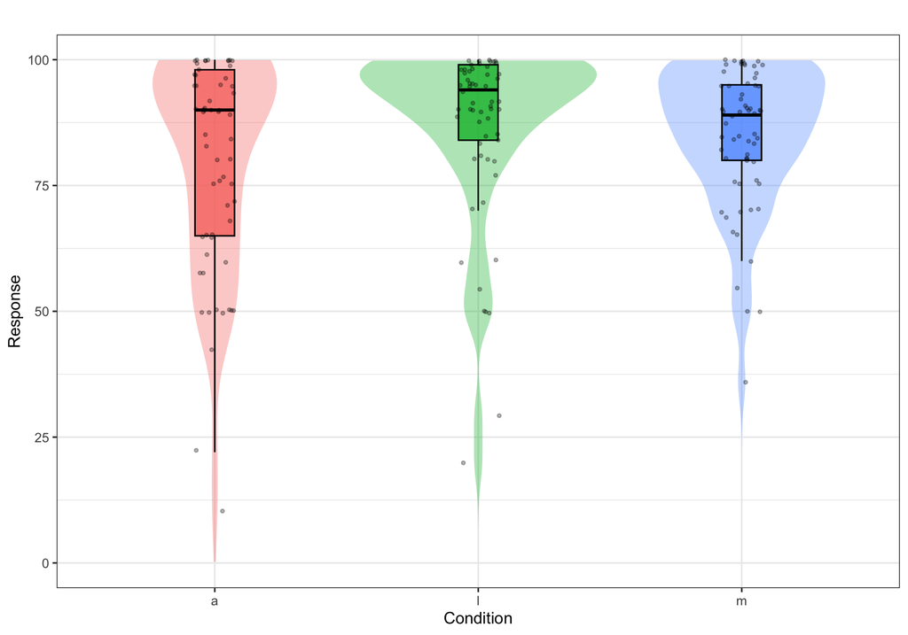

```r
ggplot(dfa_long, aes(x = condizione, y = previous_2_response,
                     fill = condizione)) +
  geom_violin(alpha = 0.35, trim = FALSE, color = NA) +
  geom_boxplot(width = 0.15, outlier.shape = NA, alpha = 0.8, color = "black") +
  geom_jitter(width = 0.08, alpha = 0.3, size = 1, color = "black") +
  ylim(c(0, 100)) +
  theme_bw(base_size = 13) +
  labs(x = "Condition", y = "Response", title = "") +
  theme(legend.position = "none")
```

## 3.3 Deterministic judgment (when the cause is absent)

`previous_3_response` captures participants’ deterministic judgment (when the candidate cause is absent).

```r
tab_causa_assente <- dfa_long %>%
  group_by(condizione) %>%
  summarise(
    Media = round(mean(previous_3_response, na.rm = TRUE), 2),
    SD    = round(sd(previous_3_response, na.rm = TRUE), 2),
    `% responses <5` = paste0(round(mean(previous_3_response < 5,
                                        na.rm = TRUE) * 100, 1), "%"),
    .groups = "drop"
  ) %>%
  rename(Condizione = condizione)

knitr::kable(tab_causa_assente, caption = "Deterministic judgment (ii)",
             align = "c")
```

Deterministic judgment (ii)

| Condizione | Media | SD | % responses <5 |
| --- | --- | --- | --- |
| a | 16.49 | 25.24 | 44.6% |
| l | 17.25 | 25.48 | 46.2% |
| m | 18.00 | 19.17 | 24.6% |

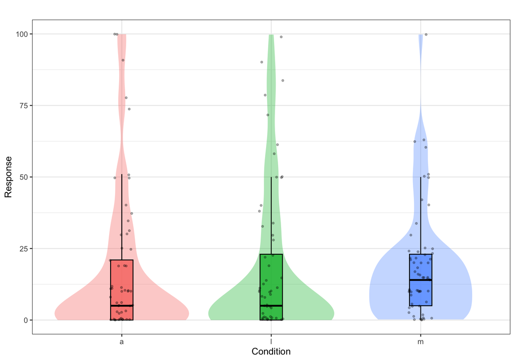

```r
ggplot(dfa_long, aes(x = condizione, y = previous_3_response, fill = condizione)) +
  geom_violin(alpha = 0.35, trim = FALSE, color = NA) +
  geom_boxplot(width = 0.15, outlier.shape = NA, alpha = 0.8, color = "black") +
  geom_jitter(width = 0.08, alpha = 0.3, size = 1, color = "black") +
  ylim(c(0, 100)) +
  theme_bw(base_size = 13) +
  labs(x = "Condition", y = "Response", title = "") +
  theme(legend.position = "none")
```

# References

```r
library(grateful)
cite_packages("paragraph", bib.file = "bib.bib", out.dir = getwd(),
              pkgs = "Session")
```

Firke, S. (2024). *janitor: Simple tools for examining and cleaning dirty data*. https://CRAN.R-project.org/package=janitor

R Core Team. (2024). *R: A language and environment for statistical computing*. R Foundation for Statistical Computing. https://www.R-project.org/

Wickham, H., Averick, M., Bryan, J., Chang, W., McGowan, L. D., François, R., Grolemund, G., Hayes, A., Henry, L., Hester, J., Kuhn, M., Pedersen, T. L., Miller, E., Bache, S. M., Müller, K., Ooms, J., Robinson, D., Seidel, D. P., Spinu, V., … Yutani, H. (2019). Welcome to the tidyverse. *Journal of Open Source Software*, *4*(43), 1686. https://doi.org/10.21105/joss.01686

Xie, Y., Cheng, J., Tan, X., & Aden-Buie, G. (2025). *DT: A wrapper of the JavaScript library “DataTables”*. https://CRAN.R-project.org/package=DT